# BIRAX study - TASMC descriptive statistics

David M Wright - d.wright@qub.ac.uk

Document compiled: 2023-09-08

R version 4.3.0 (2023-04-21 ucrt)

# 1 Introduction

This analysis is of Electronic Medical Records (EMR) from the Tel Aviv Sourasky Medical Centre extracted over the period 2014-04-27 to 2022-07-31. The aim of the study is to investigate the potential for machine learning to identify factors and biomarkers associated with long-term AMD treatment response.

This document gives descriptive statistics for various sub-groups in the dataset.

# 2 VA change by baseline visual acuity

Table 2.1: Distribution of VA changes (logMAR from baseline) at end of each year of anti-VEGF treatment by baseline VA category.

| Baseline VA Category | Level | 1 | 2 | 3 | 4 | 5 |
| --- | --- | --- | --- | --- | --- | --- |
| Good (VA>6/12) | Mean (SD) | 0.0848 (0.281) | 0.132 (0.322) | 0.186 (0.426) | 0.173 (0.36) | 0.0503 (0.203) |
| Moderate (6/24 < VA <= 6/12) | Mean (SD) | 0.127 (0.452) | 0.185 (0.494) | 0.13 (0.442) | 0.222 (0.495) | 0.178 (0.504) |
| Partially sighted (6/60 < VA <= 6/24) | Mean (SD) | 0.0327 (0.486) | 0.0191 (0.502) | 0.0502 (0.521) | 0.0484 (0.624) | 0.235 (0.859) |
| Blind (VA <= 6/60) | Mean (SD) | -0.19 (0.575) | -0.239 (0.601) | -0.291 (0.575) | -0.236 (0.717) | -0.401 (0.658) |
| Good (VA>6/12) | n | 196 | 172 | 130 | 89 | 29 |
| Moderate (6/24 < VA <= 6/12) | n | 95 | 80 | 60 | 33 | 10 |
| Partially sighted (6/60 < VA <= 6/24) | n | 115 | 94 | 54 | 31 | 8 |
| Blind (VA <= 6/60) | n | 107 | 73 | 54 | 26 | 7 |

Table 2.2: Distribution of VA change categories (from baseline) at the end of each year of anti-VEGF treatment. Ceiling effects not adjusted for.

| Baseline VA Category | Change category | 1 | 2 | 3 | 4 | 5 |
| --- | --- | --- | --- | --- | --- | --- |
| Good (VA>6/12) | Good (gained >5 letters) | 75 (35.2%) | 59 (33.3%) | 45 (34.4%) | 27 (30.7%) | 15 (44.1%) |
| Good (VA>6/12) | Partial (-5<=change<=5 letters) | 125 (58.7%) | 102 (57.6%) | 76 (58%) | 53 (60.2%) | 17 (50%) |
| Good (VA>6/12) | Non-response (lost > 5 letters) | 13 (6.1%) | 16 (9.04%) | 10 (7.63%) | 8 (9.09%) | 2 (5.88%) |
| Good (VA>6/12) | n | 213 (100%) | 177 (100%) | 131 (100%) | 88 (100%) | 34 (100%) |
| Moderate (6/24 < VA <= 6/12) | Good (gained >5 letters) | 38 (40.4%) | 28 (35.9%) | 17 (37.8%) | 8 (32%) | 1 (25%) |
| Moderate (6/24 < VA <= 6/12) | Partial (-5<=change<=5 letters) | 26 (27.7%) | 23 (29.5%) | 9 (20%) | 8 (32%) | 0 (0%) |
| Moderate (6/24 < VA <= 6/12) | Non-response (lost > 5 letters) | 30 (31.9%) | 27 (34.6%) | 19 (42.2%) | 9 (36%) | 3 (75%) |
| Moderate (6/24 < VA <= 6/12) | n | 94 (100%) | 78 (100%) | 45 (100%) | 25 (100%) | 4 (100%) |
| Partially sighted (6/60 < VA <= 6/24) | Good (gained >5 letters) | 26 (33.3%) | 21 (31.3%) | 14 (27.5%) | 6 (20.7%) | 1 (12.5%) |
| Partially sighted (6/60 < VA <= 6/24) | Partial (-5<=change<=5 letters) | 20 (25.6%) | 12 (17.9%) | 8 (15.7%) | 3 (10.3%) | 0 (0%) |
| Partially sighted (6/60 < VA <= 6/24) | Non-response (lost > 5 letters) | 32 (41%) | 34 (50.7%) | 29 (56.9%) | 20 (69%) | 7 (87.5%) |
| Partially sighted (6/60 < VA <= 6/24) | n | 78 (100%) | 67 (100%) | 51 (100%) | 29 (100%) | 8 (100%) |
| Blind (VA <= 6/60) | Good (gained >5 letters) | 26 (20.3%) | 17 (17.5%) | 14 (19.7%) | 2 (5.41%) | 0 (0%) |
| Blind (VA <= 6/60) | Partial (-5<=change<=5 letters) | 24 (18.8%) | 16 (16.5%) | 9 (12.7%) | 6 (16.2%) | 3 (37.5%) |
| Blind (VA <= 6/60) | Non-response (lost > 5 letters) | 78 (60.9%) | 64 (66%) | 48 (67.6%) | 29 (78.4%) | 5 (62.5%) |
| Blind (VA <= 6/60) | n | 128 (100%) | 97 (100%) | 71 (100%) | 37 (100%) | 8 (100%) |

# 3 Phases of functional response

The response to treatment in terms of visual acuity change can be divided into three phases:

- Primary response - measured at the first visit after the third anti-VEGF injection.
- Secondary response - measured at the second visit after the third anti-VEGF injection, provided this visit was <12 months since the first injection.
- Late response - measured at the first visit in the second year since the first injection.

The distribution of VA measurements across the phases is given in Figure 3.1. Changes in treatment response between phases are described in Tables 3.1 and 3.2. Due to the timing of some of the events, not all eyes can be assigned a complete set of phases, hence the ‘NA’ columns.

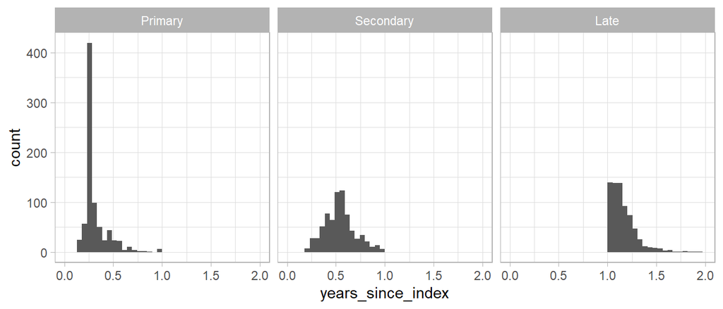

Figure 3.1: Timing of VA measurements used to represent phases of treatment response.

Table 3.1: Visual acuity changes relative to baseline in the primary and secondary phases of treatment response. Columns indicate response in the secondary phase.

| Primary response | Good (gained >5 letters) | Partial (-5<=change<=5 letters) | Non-response (lost > 5 letters) | NA |
| --- | --- | --- | --- | --- |
| Good (gained >5 letters) | 121 (64.7%) | 39 (18.5%) | 17 (11.1%) | 12 (17.6%) |
| Partial (-5<=change<=5 letters) | 51 (27.3%) | 146 (69.2%) | 44 (28.8%) | 19 (27.9%) |
| Non-response (lost > 5 letters) | 15 (8.02%) | 26 (12.3%) | 92 (60.1%) | 13 (19.1%) |

Table 3.2: Visual acuity changes relative to baseline in the secondary and late phases of treatment response. Columns indicate response in the late phase.

| Secondary response | Good (gained >5 letters) | Partial (-5<=change<=5 letters) | Non-response (lost > 5 letters) | NA |
| --- | --- | --- | --- | --- |
| Good (gained >5 letters) | 104 (61.5%) | 35 (17.7%) | 25 (14.4%) | 23 (29.5%) |
| Partial (-5<=change<=5 letters) | 33 (19.5%) | 112 (56.6%) | 45 (25.9%) | 21 (26.9%) |
| Non-response (lost > 5 letters) | 26 (15.4%) | 32 (16.2%) | 85 (48.9%) | 10 (12.8%) |

# 4 Fluid response by baseline fluid characteristics

The same classification of response phases was used to this section.

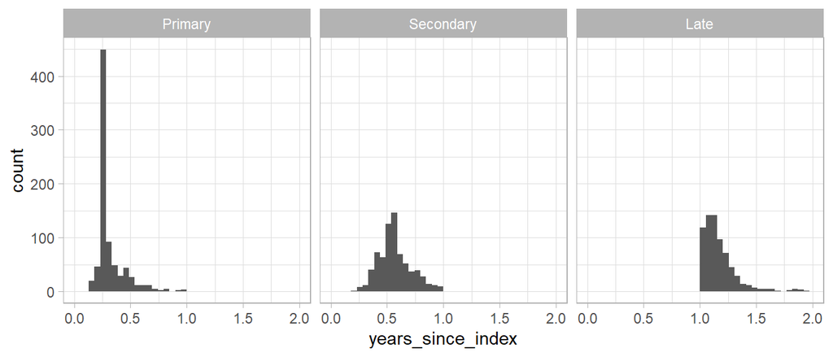

Figure 4.1: Timing of fluid measurements used to represent phases of treatment response.

Table 4.1: Fluid changes relative to baseline in the primary and secondary phases of treatment response. Columns indicate response in the secondary phase.

| Primary response | Good | Partial | Non-responder | NA |
| --- | --- | --- | --- | --- |
| Good | 190 (71.2%) | 56 (20%) | 38 (21.3%) | 32 (28.8%) |
| Partial | 51 (19.1%) | 183 (65.4%) | 27 (15.2%) | 36 (32.4%) |
| Non-responder | 26 (9.74%) | 41 (14.6%) | 113 (63.5%) | 12 (10.8%) |

[output not shown]

Table 4.3: Baseline fluid measurements by response and phase after treatment.

| Variable | amd_type | response | Level | Good | Partial | Non-responder |
| --- | --- | --- | --- | --- | --- | --- |
| Average_IRF_height[um] | SRF only | Primary | Median (IQR) | 0 (0, 0) | 0 (0, 0) | 0 (0, 0) |
| Average_IRF_height[um] | SRF only | Secondary | Median (IQR) | 0 (0, 0) | 0 (0, 0) | 0 (0, 0) |
| Average_IRF_height[um] | SRF only | Late | Median (IQR) | 0 (0, 0) | 0 (0, 0) | 0 (0, 0) |
| Average_SRF_height[um] | SRF only | Primary | Median (IQR) | 32.6 (20.3, 52) | 54.1 (42.4, 88.4) | 34.2 (22.1, 44.4) |
| Average_SRF_height[um] | SRF only | Secondary | Median (IQR) | 32.8 (21.5, 48.5) | 48.1 (31.5, 75.8) | 35 (19.1, 51.1) |
| Average_SRF_height[um] | SRF only | Late | Median (IQR) | 30.9 (19.9, 47.7) | 56 (42.4, 88.6) | 32.2 (21, 51.6) |
| Average_TRF_height[um] | SRF only | Primary | Median (IQR) | 32.6 (20.3, 52) | 54.1 (42.4, 88.4) | 34.2 (22.1, 44.4) |
| Average_TRF_height[um] | SRF only | Secondary | Median (IQR) | 32.8 (21.5, 48.5) | 48.1 (31.5, 75.8) | 35 (19.1, 51.1) |
| Average_TRF_height[um] | SRF only | Late | Median (IQR) | 30.9 (19.9, 47.7) | 56 (42.4, 88.6) | 32.2 (21, 51.6) |
| IRFVolumeNl | SRF only | Primary | Median (IQR) | 0 (0, 0) | 0 (0, 0) | 0 (0, 0) |
| IRFVolumeNl | SRF only | Secondary | Median (IQR) | 0 (0, 0) | 0 (0, 0) | 0 (0, 0) |
| IRFVolumeNl | SRF only | Late | Median (IQR) | 0 (0, 0) | 0 (0, 0) | 0 (0, 0) |
| MaxIRF_height[um] | SRF only | Primary | Median (IQR) | 0 (0, 0) | 0 (0, 0) | 0 (0, 0) |
| MaxIRF_height[um] | SRF only | Secondary | Median (IQR) | 0 (0, 0) | 0 (0, 0) | 0 (0, 0) |
| MaxIRF_height[um] | SRF only | Late | Median (IQR) | 0 (0, 0) | 0 (0, 0) | 0 (0, 0) |
| MaxSRF_height[um] | SRF only | Primary | Median (IQR) | 81.3 (46.5, 119) | 145 (105, 210) | 81.3 (46.5, 110) |
| MaxSRF_height[um] | SRF only | Secondary | Median (IQR) | 79.4 (46.5, 131) | 116 (79.4, 197) | 81.3 (46.5, 136) |
| MaxSRF_height[um] | SRF only | Late | Median (IQR) | 67.8 (46.5, 116) | 161 (105, 209) | 77.4 (45.5, 116) |
| SRFVolumeNl | SRF only | Primary | Median (IQR) | 43.9 (9.17, 136) | 354 (110, 629) | 37.3 (4.71, 110) |
| SRFVolumeNl | SRF only | Secondary | Median (IQR) | 43.9 (4.57, 139) | 161 (54.9, 548) | 41.6 (5.21, 125) |
| SRFVolumeNl | SRF only | Late | Median (IQR) | 29.1 (9.14, 125) | 319 (114, 626) | 38.6 (6.06, 78.2) |
| TRFVolumeNl | SRF only | Primary | Median (IQR) | 43.9 (9.17, 136) | 354 (110, 629) | 37.3 (4.71, 110) |
| TRFVolumeNl | SRF only | Secondary | Median (IQR) | 43.9 (4.57, 139) | 161 (54.9, 548) | 41.6 (5.21, 125) |
| TRFVolumeNl | SRF only | Late | Median (IQR) | 29.1 (9.14, 125) | 319 (114, 626) | 38.6 (6.06, 78.2) |
| Average_IRF_height[um] | IRF only | Primary | Median (IQR) | 67.5 (45.6, 114) | 78.4 (53.2, 109) | 46.7 (31.9, 77.2) |
| Average_IRF_height[um] | IRF only | Secondary | Median (IQR) | 62.1 (40.5, 90.5) | 81.1 (61.3, 114) | 54.5 (31.7, 79) |
| Average_IRF_height[um] | IRF only | Late | Median (IQR) | 63.3 (36.4, 93.2) | 73.4 (58.8, 112) | 49.4 (31.2, 79) |
| Average_SRF_height[um] | IRF only | Primary | Median (IQR) | 0 (0, 0) | 0 (0, 0) | 0 (0, 0) |
| Average_SRF_height[um] | IRF only | Secondary | Median (IQR) | 0 (0, 0) | 0 (0, 0) | 0 (0, 0) |
| Average_SRF_height[um] | IRF only | Late | Median (IQR) | 0 (0, 0) | 0 (0, 0) | 0 (0, 0) |
| Average_TRF_height[um] | IRF only | Primary | Median (IQR) | 67.5 (45.6, 114) | 78.4 (53.2, 109) | 46.7 (31.9, 77.2) |
| Average_TRF_height[um] | IRF only | Secondary | Median (IQR) | 62.1 (40.5, 90.5) | 81.1 (61.3, 114) | 54.5 (31.7, 79) |
| Average_TRF_height[um] | IRF only | Late | Median (IQR) | 63.3 (36.4, 93.2) | 73.4 (58.8, 112) | 49.4 (31.2, 79) |
| IRFVolumeNl | IRF only | Primary | Median (IQR) | 61 (14.7, 387) | 97.8 (36.7, 321) | 15.1 (3.23, 40) |
| IRFVolumeNl | IRF only | Secondary | Median (IQR) | 46.2 (10.4, 210) | 136 (64.6, 439) | 16.1 (3.27, 72.5) |
| IRFVolumeNl | IRF only | Late | Median (IQR) | 38.3 (3.96, 221) | 88.9 (27.6, 335) | 16.8 (7.19, 84) |
| MaxIRF_height[um] | IRF only | Primary | Median (IQR) | 203 (106, 313) | 217 (116, 302) | 116 (77.4, 197) |
| MaxIRF_height[um] | IRF only | Secondary | Median (IQR) | 159 (89.1, 271) | 236 (208, 391) | 126 (80.3, 208) |
| MaxIRF_height[um] | IRF only | Late | Median (IQR) | 170 (81.3, 302) | 209 (128, 327) | 124 (77.4, 205) |
| MaxSRF_height[um] | IRF only | Primary | Median (IQR) | 0 (0, 0) | 0 (0, 0) | 0 (0, 0) |
| MaxSRF_height[um] | IRF only | Secondary | Median (IQR) | 0 (0, 0) | 0 (0, 0) | 0 (0, 0) |
| MaxSRF_height[um] | IRF only | Late | Median (IQR) | 0 (0, 0) | 0 (0, 0) | 0 (0, 0) |
| SRFVolumeNl | IRF only | Primary | Median (IQR) | 0 (0, 0) | 0 (0, 0) | 0 (0, 0) |
| SRFVolumeNl | IRF only | Secondary | Median (IQR) | 0 (0, 0) | 0 (0, 0) | 0 (0, 0) |
| SRFVolumeNl | IRF only | Late | Median (IQR) | 0 (0, 0) | 0 (0, 0) | 0 (0, 0) |
| TRFVolumeNl | IRF only | Primary | Median (IQR) | 61 (14.7, 387) | 97.8 (36.7, 321) | 15.1 (3.23, 40) |
| TRFVolumeNl | IRF only | Secondary | Median (IQR) | 46.2 (10.4, 210) | 136 (64.6, 439) | 16.1 (3.27, 72.5) |
| TRFVolumeNl | IRF only | Late | Median (IQR) | 38.3 (3.96, 221) | 88.9 (27.6, 335) | 16.8 (7.19, 84) |
| Average_IRF_height[um] | SRF and IRF | Primary | Median (IQR) | 53.5 (30.2, 90.7) | 68.5 (41.3, 114) | 61.2 (40.5, 79) |
| Average_IRF_height[um] | SRF and IRF | Secondary | Median (IQR) | 61.4 (34.1, 90.1) | 65.1 (39.4, 111) | 60.9 (32.3, 84.1) |
| Average_IRF_height[um] | SRF and IRF | Late | Median (IQR) | 55.6 (31.3, 90.4) | 67 (42.2, 110) | 56.8 (32, 82.9) |
| Average_SRF_height[um] | SRF and IRF | Primary | Median (IQR) | 39.4 (24.8, 55.3) | 56.9 (36.6, 82.8) | 38.2 (23.1, 56.3) |
| Average_SRF_height[um] | SRF and IRF | Secondary | Median (IQR) | 42.5 (25.9, 61.4) | 55.2 (34.3, 82.1) | 35.2 (24.6, 49.1) |
| Average_SRF_height[um] | SRF and IRF | Late | Median (IQR) | 44.9 (32, 65.3) | 52.1 (34.5, 81.5) | 25.7 (22.2, 46.2) |
| Average_TRF_height[um] | SRF and IRF | Primary | Median (IQR) | 99.5 (64, 141) | 132 (95.4, 178) | 98.5 (81.5, 123) |
| Average_TRF_height[um] | SRF and IRF | Secondary | Median (IQR) | 110 (66.2, 152) | 122 (91.9, 173) | 97.6 (67.8, 137) |
| Average_TRF_height[um] | SRF and IRF | Late | Median (IQR) | 108 (71.2, 152) | 123 (94.3, 178) | 91.6 (50.4, 136) |
| IRFVolumeNl | SRF and IRF | Primary | Median (IQR) | 41 (3.16, 242) | 66.6 (8.58, 351) | 34.7 (8.85, 95.8) |
| IRFVolumeNl | SRF and IRF | Secondary | Median (IQR) | 42.2 (4.77, 209) | 62.9 (8.39, 305) | 24.7 (3.68, 96.8) |
| IRFVolumeNl | SRF and IRF | Late | Median (IQR) | 33.7 (3.07, 153) | 69 (9.04, 438) | 24.7 (2.34, 90.6) |
| MaxIRF_height[um] | SRF and IRF | Primary | Median (IQR) | 151 (69.7, 279) | 194 (89.1, 314) | 168 (98.7, 237) |
| MaxIRF_height[um] | SRF and IRF | Secondary | Median (IQR) | 163 (69.7, 252) | 186 (89.1, 306) | 155 (79.4, 287) |
| MaxIRF_height[um] | SRF and IRF | Late | Median (IQR) | 139 (69.7, 279) | 186 (105, 299) | 132 (77.4, 236) |
| MaxSRF_height[um] | SRF and IRF | Primary | Median (IQR) | 105 (58.1, 163) | 151 (101, 221) | 89.1 (65.8, 151) |
| MaxSRF_height[um] | SRF and IRF | Secondary | Median (IQR) | 114 (65.8, 179) | 151 (92.9, 221) | 89.1 (58.1, 145) |
| MaxSRF_height[um] | SRF and IRF | Late | Median (IQR) | 116 (71.6, 192) | 151 (92.9, 217) | 77.4 (46.5, 128) |
| SRFVolumeNl | SRF and IRF | Primary | Median (IQR) | 72.2 (13.8, 271) | 234 (46.3, 586) | 33.6 (9.42, 148) |
| SRFVolumeNl | SRF and IRF | Secondary | Median (IQR) | 99.4 (20.7, 261) | 257 (43.9, 552) | 31.8 (10.4, 123) |
| SRFVolumeNl | SRF and IRF | Late | Median (IQR) | 145 (21.6, 344) | 209 (33.9, 533) | 27 (8.97, 77.7) |
| TRFVolumeNl | SRF and IRF | Primary | Median (IQR) | 217 (54, 538) | 478 (221, 1310) | 117 (41.9, 358) |
| TRFVolumeNl | SRF and IRF | Secondary | Median (IQR) | 231 (55.1, 645) | 468 (182, 1280) | 117 (35.6, 255) |
| TRFVolumeNl | SRF and IRF | Late | Median (IQR) | 263 (104, 562) | 461 (166, 1320) | 78.1 (15.8, 325) |

Figures 4.2 and 4.3 and Table 4.4 do not include those where fluid never resolved.

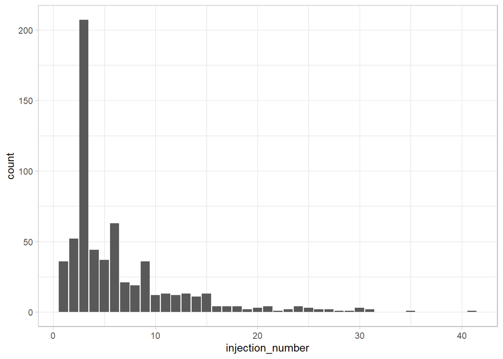

Figure 4.2: Number of injections required to achieve fluid resolution.

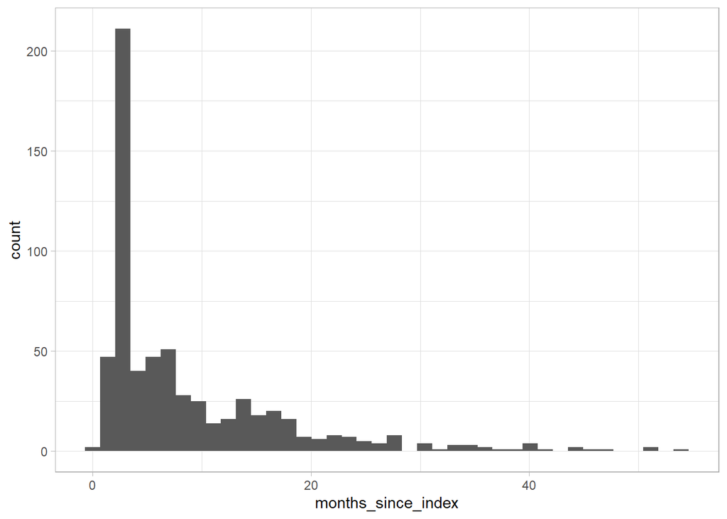

Figure 4.3: Time required to achieve fluid resolution.

Table 4.4: Time and number injections required to achieve fluid resolution.

| Variable | Level | Value |
| --- | --- | --- |
| injection_number | n | 633 |
| injection_number | Mean (SD) | 6.42 (5.86) |
| injection_number | Median (IQR) | 4 (3, 8) |
| months_since_index | n | 633 |
| months_since_index | Mean (SD) | 8.93 (8.97) |
| months_since_index | Median (IQR) | 5.32 (3.02, 12.4) |

# 5 Number of annual injections

The number of injections per year was calculated across treatment years 2 and 3 (i.e. total number of injections / 2). This rate was categorised into three groups and used to classify various outcomes.

Table 5.1: VA at baseline by number of injections per year in years 2-3 (aggregated).

| Variable | Level | 0.5 <= x <= 4 | 4 < x <= 7 | 7 < x <= 12 |
| --- | --- | --- | --- | --- |
| va_logmar | Median (IQR) | 0.49 (0.19, 1.02) | 0.36 (0.19, 0.71) | 0.36 (0.19, 0.66) |
| va_category_snellen | Good (VA>6/12) | 91 (34.7%) | 81 (43.3%) | 89 (45.4%) |
| va_category_snellen | Moderate (6/24 < VA <= 6/12) | 41 (15.6%) | 41 (21.9%) | 45 (23%) |
| va_category_snellen | Partially sighted (6/60 < VA <= 6/24) | 64 (24.4%) | 33 (17.6%) | 41 (20.9%) |
| va_category_snellen | Blind (VA <= 6/60) | 66 (25.2%) | 32 (17.1%) | 21 (10.7%) |
| Eyes | n | 262 (100%) | 187 (100%) | 196 (100%) |

Table 5.2: AMD type at baseline (SRF/IRF status) by number of injections per year in years 2-3 (aggregated).

| AMD type | 0.5 <= x <= 4 | 4 < x <= 7 | 7 < x <= 12 |
| --- | --- | --- | --- |
| No fluid | 26 (10.4%) | 21 (11.3%) | 14 (7.29%) |
| SRF only | 48 (19.1%) | 46 (24.7%) | 62 (32.3%) |
| IRF only | 55 (21.9%) | 37 (19.9%) | 31 (16.1%) |
| SRF and IRF | 122 (48.6%) | 82 (44.1%) | 85 (44.3%) |

Table 5.3: Baseline fluid measurements by number of injections per year in years 2-3 (aggregated).

| Variable | Level | 0.5 <= x <= 4 | 4 < x <= 7 | 7 < x <= 12 |
| --- | --- | --- | --- | --- |
| SRFVolumeNl | Median (IQR) | 16.1 (0, 164) | 24.7 (0, 240) | 44 (0.525, 314) |
| IRFVolumeNl | Median (IQR) | 16.2 (0, 103) | 3.66 (0, 103) | 1.88 (0, 59.2) |
| TRFVolumeNl | Median (IQR) | 102 (15.1, 441) | 103 (9.89, 432) | 123 (26.8, 508) |
| Average_IRF_height[um] | Median (IQR) | 45.2 (0, 78.4) | 33.3 (0, 72) | 27.3 (0, 69.7) |
| Average_SRF_height[um] | Median (IQR) | 25.9 (0, 51) | 30.7 (0, 52.6) | 35.3 (11.3, 59.7) |
| Average_TRF_height[um] | Median (IQR) | 78 (35.9, 118) | 65.3 (31.4, 115) | 70.2 (39.1, 115) |
| MaxIRF_height[um] | Median (IQR) | 112 (0, 225) | 77.4 (0, 205) | 56.1 (0, 189) |
| MaxSRF_height[um] | Median (IQR) | 65.8 (0, 141) | 71.6 (0, 151) | 83.2 (26.1, 159) |
| Eyes | n | 251 | 186 | 192 |

Table 5.4: Number of injections in the first year by number of injections per year in years 2-3 (aggregated).

| Level | 0.5 <= x <= 4 | 4 < x <= 7 | 7 < x <= 12 |
| --- | --- | --- | --- |
| Median (IQR) | 8 (6, 9) | 9 (7, 10) | 10 (8, 11) |
| Eyes | 271 | 195 | 197 |

Table 5.5: Initial treatment response (primary phase) by number of injections per year in years 2-3 (aggregated).

| Primary response | 0.5 <= x <= 4 | 4 < x <= 7 | 7 < x <= 12 |
| --- | --- | --- | --- |
| Good (gained >5 letters) | 61 (31.3%) | 44 (34.4%) | 48 (33.8%) |
| Partial (-5<=change<=5 letters) | 79 (40.5%) | 58 (45.3%) | 68 (47.9%) |
| Non-response (lost > 5 letters) | 55 (28.2%) | 26 (20.3%) | 26 (18.3%) |